# Simple Linear Regression

```r
library(tidyverse)
library(moderndive)
library(skimr)
library(gapminder)
```

In this notebook I explore simple linear regression. SLR is linear regression in a single variable, predicting a numerical output variable.

Let’s start with some EDA to understand the shape of the data.

```r
evals_beauty <- evals %>%
  select(ID, score, bty_avg, age)
glimpse(evals_beauty)
```

```
Rows: 463
Columns: 4
$ ID      <int> 1, 2, 3, 4, 5, 6, 7, 8, 9, 10, 11, 12, 13, 14, 15, 16, 17, 18, 19, 20, 21, 22, 23, 24, 25, 26, 27, 28, 29, 30, 31, 32…
$ score   <dbl> 4.7, 4.1, 3.9, 4.8, 4.6, 4.3, 2.8, 4.1, 3.4, 4.5, 3.8, 4.5, 4.6, 3.9, 3.9, 4.3, 4.5, 4.8, 4.6, 4.6, 4.9, 4.6, 4.5, 4.…
$ bty_avg <dbl> 5.000, 5.000, 5.000, 5.000, 3.000, 3.000, 3.000, 3.333, 3.333, 3.167, 3.167, 3.167, 3.167, 3.167, 3.167, 3.167, 3.167…
$ age     <int> 36, 36, 36, 36, 59, 59, 59, 51, 51, 40, 40, 40, 40, 40, 40, 40, 40, 31, 31, 31, 31, 31, 31, 62, 62, 62, 62, 62, 62, 6…
```

```r
evals_beauty %>%
   select(score, bty_avg, age) %>%
  skim()
```

```
── Data Summary ────────────────────────
                           Values
Name                       Piped data
Number of rows             463
Number of columns          3
_______________________
Column type frequency:
  numeric                  3
________________________
Group variables            None

── Variable type: numeric ─────────────────────────────────────────────────────────────────────────────────────────────────────────────
  skim_variable n_missing complete_rate  mean    sd    p0   p25   p50   p75  p100 hist
1 score                 0             1  4.17 0.544  2.3   3.8   4.3    4.6  5    ▁▁▅▇▇
2 bty_avg               0             1  4.42 1.53   1.67  3.17  4.33   5.5  8.17 ▃▇▇▃▂
3 age                   0             1 48.4  9.80  29    42    48     57   73    ▅▆▇▆▁
```

```r
evals_beauty %>%
  get_correlation(formula = score ~ bty_avg)
```

| cor |
| --- |
| 0.1871424 |

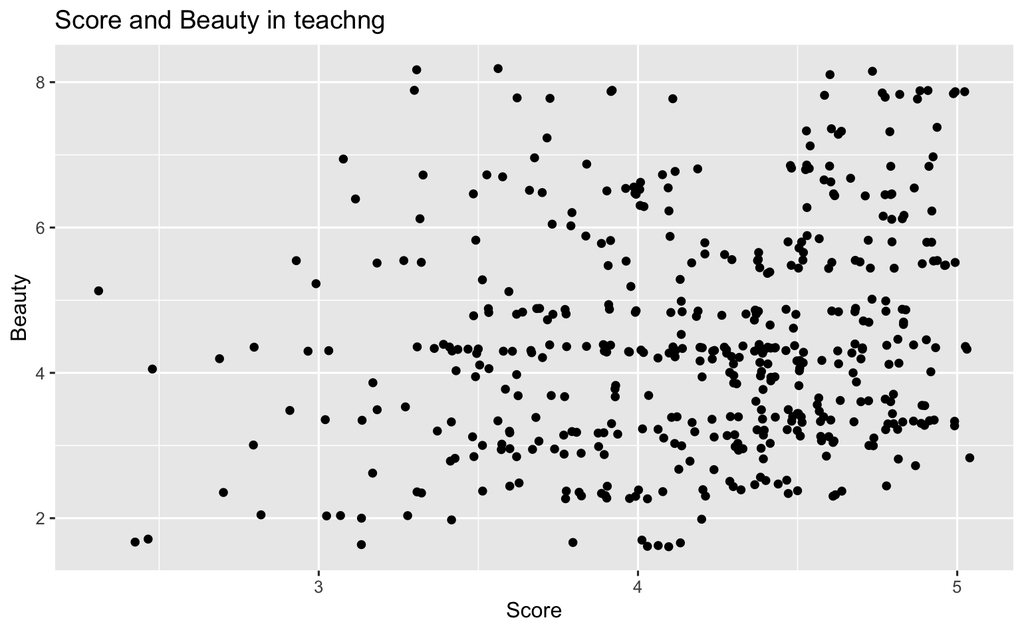

```r
ggplot(evals_beauty, mapping = aes(x = score, y = bty_avg)) +
  geom_jitter() +
  labs(x = "Score",
       y= "Beauty",
       title = "Score and Beauty in teachng")
```

You can add a fit line to visualizations using the technique of choice. The technique is provided as a string of the function name.

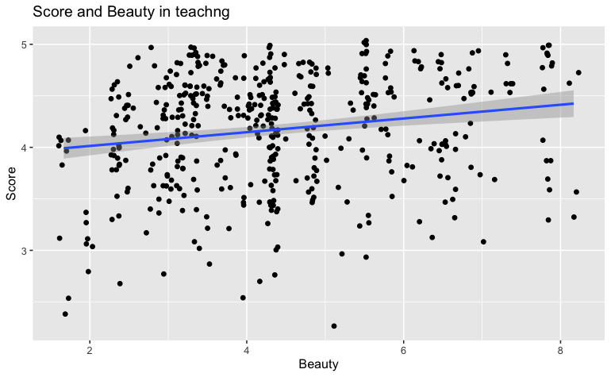

```r
ggplot(evals_beauty, mapping = aes(y = score, x = bty_avg)) +
  geom_jitter() +
  labs(y = "Score",
       x= "Beauty",
       title = "Score and Beauty in teachng") +
  geom_smooth(method="lm")
```

The line plotted above is called a regression line. It illustrates the impact that a change in beauty has on score. In this case, the slope is quite low, as fitting the low positive correlation between beauty and score.To determine a predicted score based on the beauty_avg, let’s run a linear regresson.

```r
model <- lm(score ~ bty_avg, evals)
get_regression_table(model)
```

| term | estimate | std_error | statistic | p_value | lower_ci | upper_ci |
| --- | --- | --- | --- | --- | --- | --- |
| intercept | 3.880 | 0.076 | 50.961 | 0 | 3.731 | 4.030 |
| bty_avg | 0.067 | 0.016 | 4.090 | 0 | 0.035 | 0.099 |

The regression table above shows that the majority of the score comes from the intercept rather than the effect of beauty. That fits with the low correlation found earlier.The `lm` function trains a linear model based on the provied forumla.

Open question: How to train a model in multiple variables?

Same analysis but for age:

```r
age_model <- lm(score ~ age, evals)
get_regression_table(age_model)
```

| term | estimate | std_error | statistic | p_value | lower_ci | upper_ci |
| --- | --- | --- | --- | --- | --- | --- |
| intercept | 4.462 | 0.127 | 35.195 | 0.000 | 4.213 | 4.711 |
| age | -0.006 | 0.003 | -2.311 | 0.021 | -0.011 | -0.001 |

```r
get_regression_points(model)
```

| ID | score | bty_avg | score_hat | residual |
| --- | --- | --- | --- | --- |
| 1 | 4.7 | 5.000 | 4.214 | 0.486 |
| 2 | 4.1 | 5.000 | 4.214 | -0.114 |
| 3 | 3.9 | 5.000 | 4.214 | -0.314 |
| 4 | 4.8 | 5.000 | 4.214 | 0.586 |
| 5 | 4.6 | 3.000 | 4.080 | 0.520 |
| 6 | 4.3 | 3.000 | 4.080 | 0.220 |
| 7 | 2.8 | 3.000 | 4.080 | -1.280 |
| 8 | 4.1 | 3.333 | 4.102 | -0.002 |
| 9 | 3.4 | 3.333 | 4.102 | -0.702 |
| 10 | 4.5 | 3.167 | 4.091 | 0.409 |

[output cut: 453 more lines]

Flipping over to look at regression with a single categorical variable. Open question: How to mix categorical and numerical variables together in a regression?

```r
library(gapminder)

gapminder2007 <- gapminder %>%
  filter(year == 2007) %>%
  select(- year)

glimpse(gapminder2007)
```

```
Rows: 142
Columns: 5
$ country   <fct> "Afghanistan", "Albania", "Algeria", "Angola", "Argentina", "Australia", "Austria", "Bahrain", "Bangladesh…
$ continent <fct> Asia, Europe, Africa, Africa, Americas, Oceania, Europe, Asia, Asia, Europe, Africa, Americas, Europe, Afr…
$ lifeExp   <dbl> 43.828, 76.423, 72.301, 42.731, 75.320, 81.235, 79.829, 75.635, 64.062, 79.441, 56.728, 65.554, 74.852, 50…
$ pop       <int> 31889923, 3600523, 33333216, 12420476, 40301927, 20434176, 8199783, 708573, 150448339, 10392226, 8078314, …
$ gdpPercap <dbl> 974.5803, 5937.0295, 6223.3675, 4797.2313, 12779.3796, 34435.3674, 36126.4927, 29796.0483, 1391.2538, 3369…
```

```r
gapminder2007 %>% sample_n(10)
```

| country | continent | lifeExp | pop | gdpPercap |
| --- | --- | --- | --- | --- |
| Senegal | Africa | 63.062 | 12267493 | 1712.4721 |
| Cambodia | Asia | 59.723 | 14131858 | 1713.7787 |
| Iraq | Asia | 59.545 | 27499638 | 4471.0619 |
| Libya | Africa | 73.952 | 6036914 | 12057.4993 |
| Tunisia | Africa | 73.923 | 10276158 | 7092.9230 |
| Congo, Dem. Rep. | Africa | 46.462 | 64606759 | 277.5519 |
| Botswana | Africa | 50.728 | 1639131 | 12569.8518 |
| Serbia | Europe | 74.002 | 10150265 | 9786.5347 |
| China | Asia | 72.961 | 1318683096 | 4959.1149 |
| Namibia | Africa | 52.906 | 2055080 | 4811.0604 |

```r
skim(gapminder2007)
```

```
── Data Summary ────────────────────────
                           Values
Name                       gapminder2007
Number of rows             142
Number of columns          5
_______________________
Column type frequency:
  factor                   2
  numeric                  3
________________________
Group variables            None

── Variable type: factor ─────────────────────────────────────────────────────────────────────────────────────────────────────
  skim_variable n_missing complete_rate ordered n_unique top_counts
1 country               0             1 FALSE        142 Afg: 1, Alb: 1, Alg: 1, Ang: 1
2 continent             0             1 FALSE          5 Afr: 52, Asi: 33, Eur: 30, Ame: 25

── Variable type: numeric ────────────────────────────────────────────────────────────────────────────────────────────────────
  skim_variable n_missing complete_rate       mean          sd       p0       p25        p50        p75         p100 hist
1 lifeExp               0             1       67.0        12.1     39.6      57.2       71.9       76.4         82.6 ▂▃▃▆▇
2 pop                   0             1 44021220.  147621398.  199579   4508034.  10517531   31210042.  1318683096   ▇▁▁▁▁
3 gdpPercap             0             1    11680.      12860.     278.     1625.      6124.     18009.       49357.  ▇▂▁▂▁
```

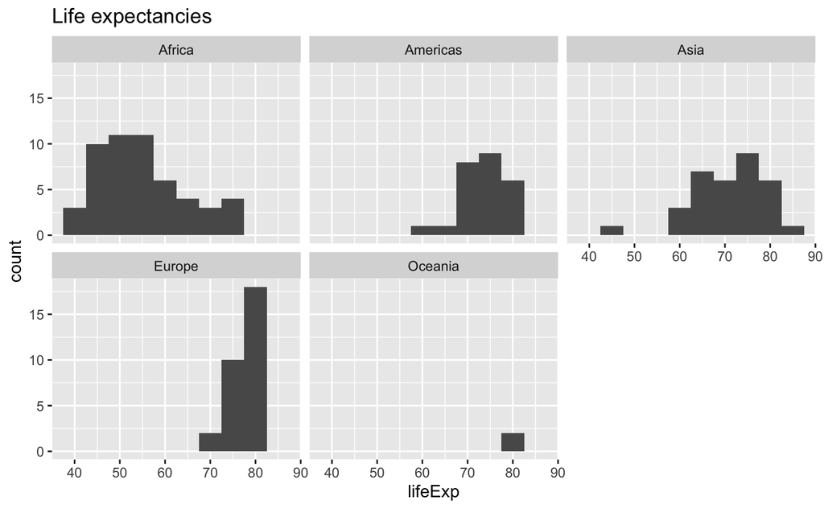

```r
ggplot(gapminder2007, mapping=aes(x=lifeExp)) +
  geom_histogram(binwidth = 5) +
  labs(title="Life expectancies") +
  facet_wrap(~ continent)
```

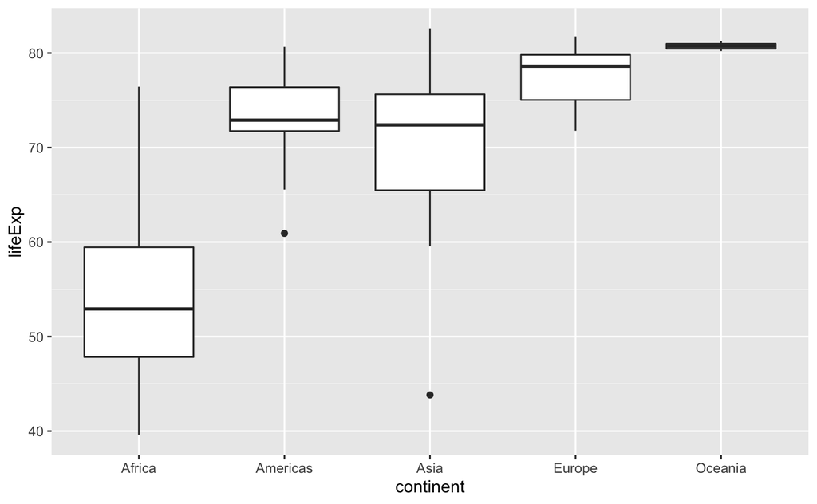

```r
ggplot(gapminder2007, mapping=aes(x=continent, y= lifeExp)) +
  geom_boxplot()
```

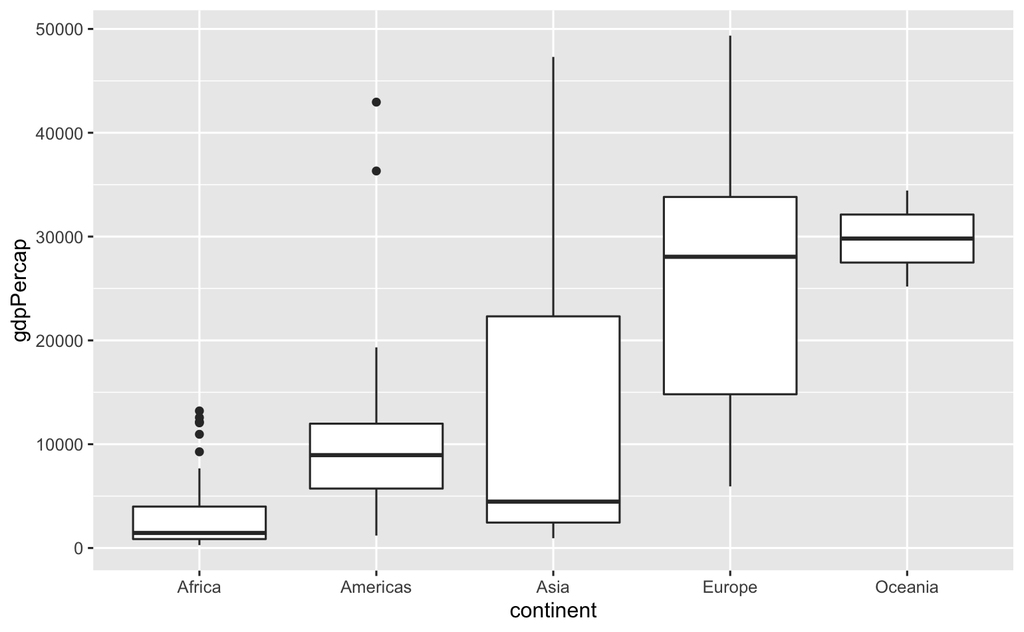

```r
ggplot(gapminder2007, mapping=aes(x=continent, y=gdpPercap)) +
  geom_boxplot()
```

Regresson tables use the first category as the intercept. that’s illustrated in the following two regresson tables. The estimated values for any given category are the `intercept + estimate`. Mathematically, this works by applying an indicator function to each pair of (coefficient, value).

```r
gdp_model <-lm(gdpPercap ~ continent, gapminder2007)
get_regression_table(gdp_model)
```

| term | estimate | std_error | statistic | p_value | lower_ci | upper_ci |
| --- | --- | --- | --- | --- | --- | --- |
| intercept | 3089.033 | 1372.738 | 2.250 | 0.026 | 374.538 | 5803.527 |
| continentAmericas | 7913.999 | 2409.145 | 3.285 | 0.001 | 3150.080 | 12677.918 |
| continentAsia | 9383.994 | 2203.130 | 4.259 | 0.000 | 5027.457 | 13740.532 |
| continentEurope | 21965.449 | 2269.519 | 9.678 | 0.000 | 17477.631 | 26453.267 |
| continentOceania | 26721.156 | 7132.955 | 3.746 | 0.000 | 12616.228 | 40826.083 |

```r
life_model <- lm(lifeExp ~ continent, gapminder2007)
get_regression_table(life_model)
```

| term | estimate | std_error | statistic | p_value | lower_ci | upper_ci |
| --- | --- | --- | --- | --- | --- | --- |
| intercept | 54.806 | 1.025 | 53.446 | 0 | 52.778 | 56.834 |
| continentAmericas | 18.802 | 1.800 | 10.448 | 0 | 15.243 | 22.361 |
| continentAsia | 15.922 | 1.646 | 9.675 | 0 | 12.668 | 19.177 |
| continentEurope | 22.843 | 1.695 | 13.474 | 0 | 19.490 | 26.195 |
| continentOceania | 25.913 | 5.328 | 4.863 | 0 | 15.377 | 36.450 |

What about computing residuals directly?

```r
get_regression_points(model) %>%
  mutate(sq_resid = residual^2) %>%
  summarise(summed_residual = sum(sq_resid))
```

| summed_residual |
| --- |
| 131.8785 |